# QALL401: Data Analysis for Researchers

## Course Contents

1. 2022.12.07: Introduction: About the course [lead by TK]
   - An introduction to open and public data, and data science
2. 2022-12-14: Exploratory Data Analysis (EDA) 1 [lead by hs]
   - R Basics with RStudio and/or RStudio.cloud; Toy Data
3. 2022-12-21: Exploratory Data Analysis (EDA) 2 [lead by hs]
   - R Markdown, `tidyverse` I: `dplyr`; `gapminder`
4. 2023-01-11: Exploratory Data Analysis (EDA) 3 [lead by hs]
   - `tidyverse`II: `readr`, `ggplot2`; Public Data, WDI, WIR, etc
5. 2023-01-18: Exploratory Data Analysis (EDA) 4 [lead by hs]
   - `tidyverse` III: `tidyr`, etc.; WDI, WIR, etc
6. **2023-01-25: Exploratory Data Analysis (EDA) 5 [lead by hs]**
   - `tidyverse` IV; WDI, WIR, etc
7. 2023-02-01: Introduction to PPDAC
   - Problem-Plan-Data-Analysis-Conclusion Cycle: [lead by TK]
8. 2023-02-08: Model building I [lead by TK]
   - Collecting and visualizing data and Introduction to WDI  
     (World Development Indicators by World Bank)
9. 2023-02-15: Model building II [lead by TK]
   - Analyzing data and communications
10. 2023-02-22: Project Presentation

# 1 Exploratory Data Analysis (EDA) I

# 2 Exploratory Data Analysis II

# 3 Exploratory Data Analysis III

# 4 Exploratory Data Analysis (EDA) IV

# 5 Exploratory Data Analysis (EDA) V

### Setup

```r
library(tidyverse)
library(WDI)
library(readxl)
library(broom)
```

- broom: https://cran.r-project.org/web/packages/broom/index.html
- Introduction to broom: https://cran.r-project.org/web/packages/broom/vignettes/broom.html

## 5.1 Modeling

### 5.1.1 What is modeling in EDA

Model is a simple summary of data

Goal: A simple low-dimensional summary of a dataset. Ideally, the model will capture true “signals” (i.e. patterns generated by the phenomenon of interest), and ignore “noise” (i.e. random variation that you’re not interested in).

```r
df0 <- as_tibble(iris) %>% filter(Species != "setosa")
```

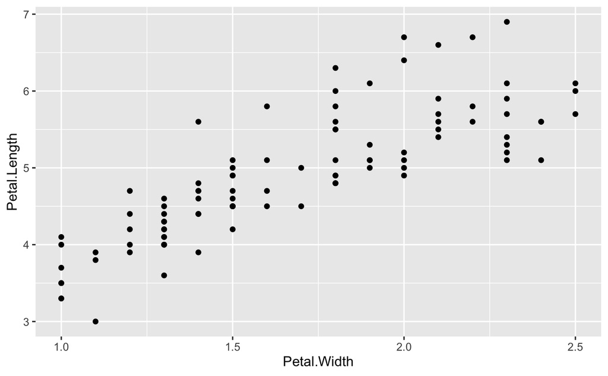

```r
df0 %>% ggplot(aes(Petal.Width, Petal.Length)) + geom_point()
```

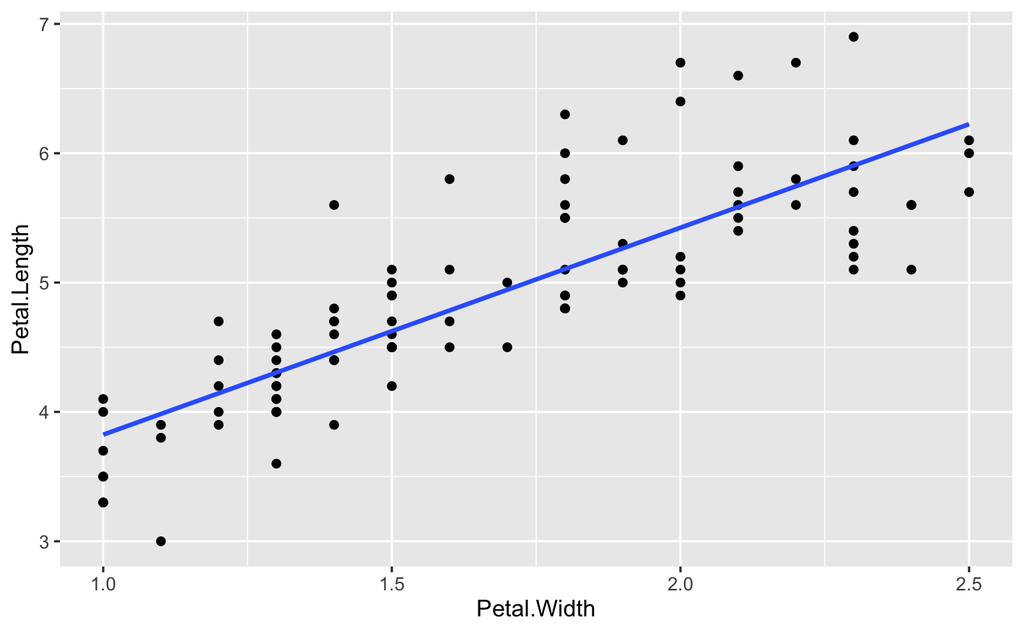

```r
df0 %>% ggplot(aes(Petal.Width, Petal.Length)) + geom_point() + geom_smooth(method="lm",formula=y~x, se=FALSE)
```

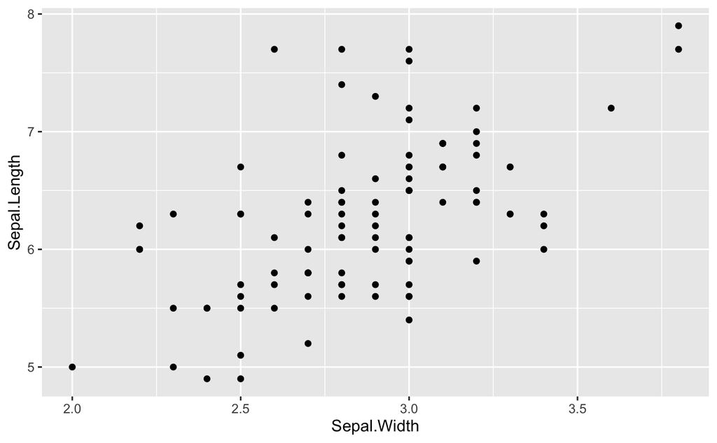

```r
df0 %>% ggplot(aes(Sepal.Width, Sepal.Length)) + geom_point()
```

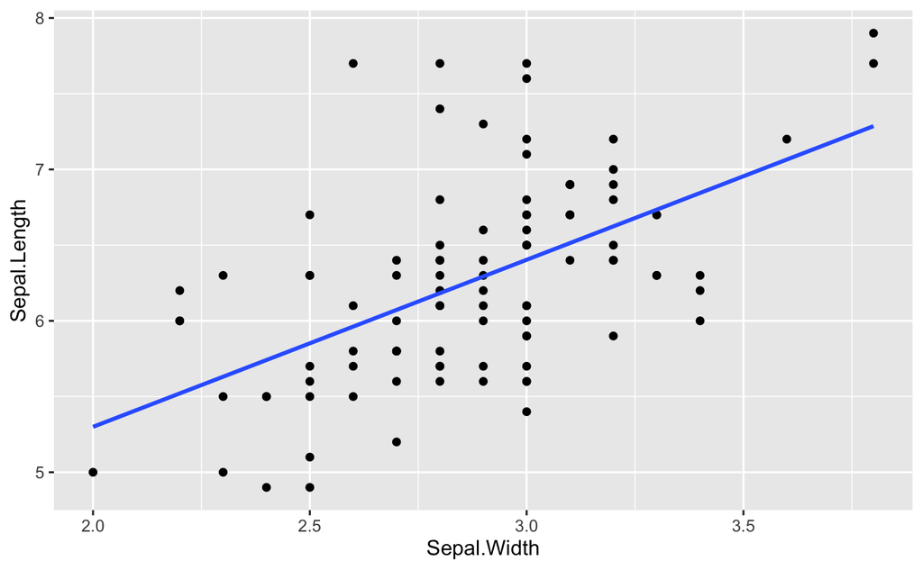

```r
df0 %>% ggplot(aes(Sepal.Width, Sepal.Length)) + geom_point() + geom_smooth(method="lm",formula=y~x, se=FALSE)
```

### 5.1.2 Linear Model: Petal.Length ~ Petal.Width

```r
df0 %>% lm(Petal.Length ~ Petal.Width, .)
```

```
Call:
lm(formula = Petal.Length ~ Petal.Width, data = .)

Coefficients:
(Intercept)  Petal.Width
      2.224        1.600
```

### 5.1.3 Formula: $\text{Petal.Length} = 2.224 + 1.600\cdot \text{Petal.Width}$

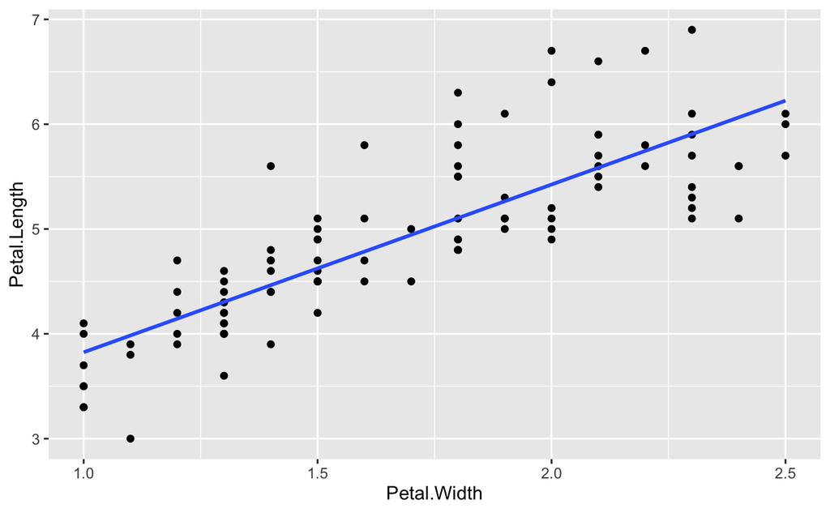

### 5.1.4 Linear Model: Sepal.Length ~ Sepal.Width

```r
df0 %>% lm(Sepal.Length ~ Sepal.Width, .)
```

```
Call:
lm(formula = Sepal.Length ~ Sepal.Width, data = .)

Coefficients:
(Intercept)  Sepal.Width
      3.093        1.103
```

### 5.1.5 Formula: $\text{Sepal.Length} = 3.093 + 1.103\cdot \text{Sepal.Width}$

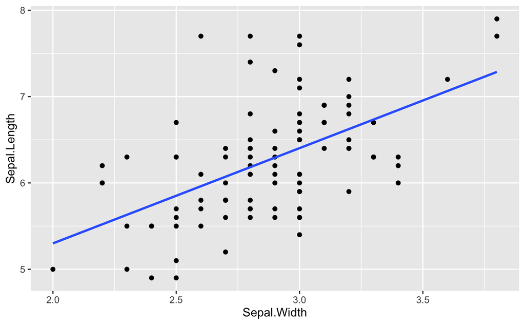

### 5.1.6 Petal.Length ~ Petal.Width: R squared = 0.6779 - 68%

```r
df0 %>% lm(Petal.Length ~ Petal.Width, .) %>% summary()
```

```
Call:
lm(formula = Petal.Length ~ Petal.Width, data = .)

Residuals:
    Min      1Q  Median      3Q     Max
-0.9842 -0.3043 -0.1043  0.2407  1.2755

Coefficients:
            Estimate Std. Error t value Pr(>|t|)
(Intercept)   2.2240     0.1926   11.55   <2e-16 ***
Petal.Width   1.6003     0.1114   14.36   <2e-16 ***
---
Signif. codes:  0 ‘***’ 0.001 ‘**’ 0.01 ‘*’ 0.05 ‘.’ 0.1 ‘ ’ 1

Residual standard error: 0.4709 on 98 degrees of freedom
Multiple R-squared:  0.6779,    Adjusted R-squared:  0.6746
F-statistic: 206.3 on 1 and 98 DF,  p-value: < 2.2e-16
```

### 5.1.7 Sepal.Length ~ Sepal.Width: R squared = 0.3068 - 31%

```r
df0 %>% lm(Sepal.Length ~ Sepal.Width, .) %>% summary()
```

```
Call:
lm(formula = Sepal.Length ~ Sepal.Width, data = .)

Residuals:
    Min      1Q  Median      3Q     Max
-1.0032 -0.3877 -0.0774  0.3200  1.7381

Coefficients:
            Estimate Std. Error t value Pr(>|t|)
(Intercept)   3.0934     0.4844   6.387 5.70e-09 ***
Sepal.Width   1.1033     0.1675   6.585 2.27e-09 ***
---
Signif. codes:  0 ‘***’ 0.001 ‘**’ 0.01 ‘*’ 0.05 ‘.’ 0.1 ‘ ’ 1

Residual standard error: 0.5547 on 98 degrees of freedom
Multiple R-squared:  0.3068,    Adjusted R-squared:  0.2997
F-statistic: 43.36 on 1 and 98 DF,  p-value: 2.27e-09
```

### 5.1.8 Linear Model Basics: y ~ x

```
lm(y~x, data)
```

```
data %>% lm(y~x, .)
```

y-intercept, and slope: rate of increase or decrease

```
summary(lm(y~x, data))
```

```
data %>% lm(y~x, .) %>% summary()
```

(Multiple) R Squared: a value between 0 and 1, strength of the model

[figure not shown]

```r
df1 <- data.frame(x = c(1,2,3,4), y = c(1,0.5,2, 1.5))
ybar <- mean(df1$y)
mod1 <- lm(y~x, df1)
augment(mod1) %>% ggplot() + geom_point(aes(x,y)) + geom_smooth(aes(x,y), formula = y~x, method = "lm", se = FALSE) + geom_hline(yintercept = ybar, linetype="longdash", col = "red") + geom_point(aes(x, ybar), shape=4) + geom_point(aes(x, .fitted), shape =9, size=2) + geom_text(aes(x, ybar, label = paste0("(",x,",",1.25,")")), nudge_y = -0.1, col = "red") + geom_text(aes(x, .fitted, label = paste0("(",x,",",.fitted,")")), nudge_y = -0.1, col = "blue") + geom_text(aes(x, y, label = paste0("(",x,",",y,")")), nudge_y = -0.1)
```

- $(x_1, y_1)$, $(x_2,y_2)$, $(x_3, y_3)$, $(x_4, y_4)$: Data points
- $\bar{y}$: mean of y = $(y_1 + y_2 + y_3 + y_4)/4$.
- $\hat{y}_i$: prediction at $x_i$,
  - $(x_1, \hat{y}_1)$, $(x_2, \hat{y}_2)$, $(x_3, \hat{y}_3)$, $(x_4, \hat{y}_4)$ are on the regression line.
- $y_1-\hat{y}_1$, $y_2-\hat{y}_2$, $y_2-\hat{y}_2$, $y_2-\hat{y}_2$ are called residues.

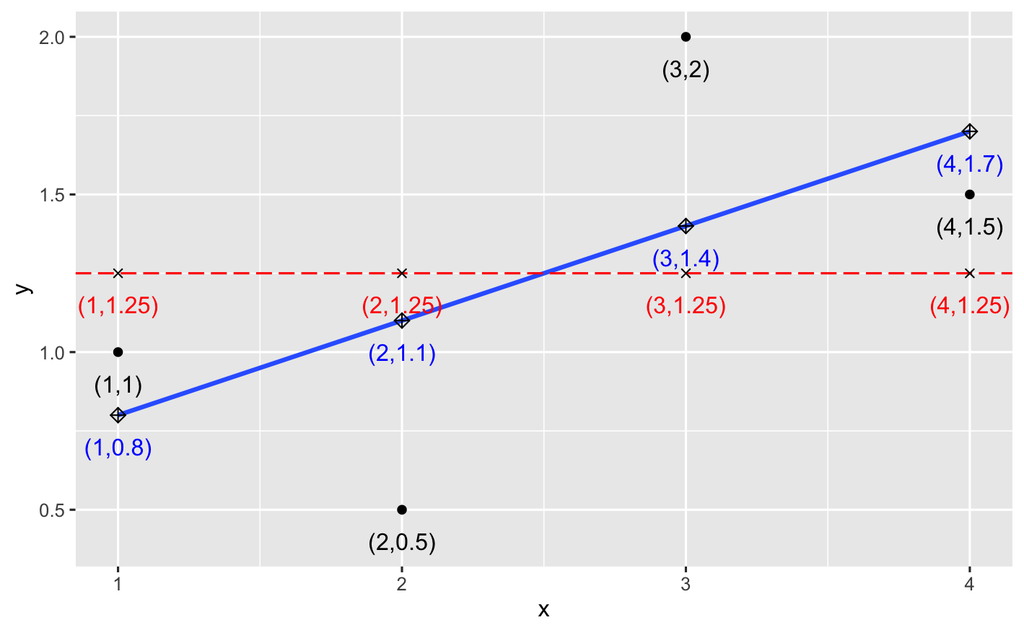

### 5.1.9 R Squared

$$SS_{tot} = (1-1.25)^2 + (0.5-1.25)^2 +
(2-1.25)^2 + (1.5-1.25)^2 = 1.25$$
$$SS_{res} = (1-0.8)^2 + (0.5-1.1)^2 + (2-1.4)^2 +
(1.5-1.7)^2 = 0.8$$
$$R^2 = 1 -
\frac{SS_{res}}{SS_{tot}} = 1- \frac{0.8}{1.25} = 0.36.$$

```r
summary(mod1)$r.squared
```

```
[1] 0.36
```

```r
mod1 %>% glance() %>% pull(r.squared)
```

```
[1] 0.36
```

```r
mod1 %>% glance() %>% select(`R Squared` = r.squared)
```

| R Squared |
| --- |
| 0.36 |

```r
mod1 %>% summary() %>% glimpse()
```

```
List of 11
 $ call         : language lm(formula = y ~ x, data = df1)
 $ terms        :Classes 'terms', 'formula'  language y ~ x
  .. ..- attr(*, "variables")= language list(y, x)
  .. ..- attr(*, "factors")= int [1:2, 1] 0 1
  .. .. ..- attr(*, "dimnames")=List of 2
  .. ..- attr(*, "term.labels")= chr "x"
  .. ..- attr(*, "order")= int 1
  .. ..- attr(*, "intercept")= int 1
  .. ..- attr(*, "response")= int 1
  .. ..- attr(*, ".Environment")=<environment: R_GlobalEnv>
  .. ..- attr(*, "predvars")= language list(y, x)
  .. ..- attr(*, "dataClasses")= Named chr [1:2] "numeric" "numeric"
  .. .. ..- attr(*, "names")= chr [1:2] "y" "x"
 $ residuals    : Named num [1:4] 0.2 -0.6 0.6 -0.2
  ..- attr(*, "names")= chr [1:4] "1" "2" "3" "4"
 $ coefficients : num [1:2, 1:4] 0.5 0.3 0.775 0.283 0.645 ...
  ..- attr(*, "dimnames")=List of 2
  .. ..$ : chr [1:2] "(Intercept)" "x"
  .. ..$ : chr [1:4] "Estimate" "Std. Error" "t value" "Pr(>|t|)"
 $ aliased      : Named logi [1:2] FALSE FALSE
  ..- attr(*, "names")= chr [1:2] "(Intercept)" "x"
 $ sigma        : num 0.632
 $ df           : int [1:3] 2 2 2
 $ r.squared    : num 0.36
 $ adj.r.squared: num 0.04
 $ fstatistic   : Named num [1:3] 1.12 1 2
  ..- attr(*, "names")= chr [1:3] "value" "numdf" "dendf"
 $ cov.unscaled : num [1:2, 1:2] 1.5 -0.5 -0.5 0.2
  ..- attr(*, "dimnames")=List of 2
  .. ..$ : chr [1:2] "(Intercept)" "x"
  .. ..$ : chr [1:2] "(Intercept)" "x"
 - attr(*, "class")= chr "summary.lm"
```

### 5.1.10 Useful Mathematical Formula

$$\begin{align}
\mbox{slope of the regression line} &= \frac{cov(x,y)}{var(x)} =
\frac{cor(x,y)\sqrt{var(y)}}{\sqrt{var(x)}}\\
\mbox{total sum of squares} &= SS_{tot} = \sum_{i}(y_i-mean(y))^2\\
\mbox{residual sum of squares} &= SS_{res} =
\sum_{i}(y_i-\mbox{pred}_i)^2 = \sum_{i}(y_i-\hat{y}_i)^2\\
\mbox{R squared} = R^2 & = 1 - \frac{SS_{res}}{SS_{tot}} =
cor(x,y)^2
\end{align}$$

### 5.1.11 Adjusted R Squared

$$\text{Adjusted }R^2 = 1-
\frac{(1-R^2)(n-1)}{n-k-1}$$
$n$: number of observations, the number of rows

$k$: number of variables used for prediction

```r
df0 %>% select(1:4) %>% cor()
```

```
             Sepal.Length Sepal.Width Petal.Length Petal.Width
Sepal.Length    1.0000000   0.5538548    0.8284787   0.5937094
Sepal.Width     0.5538548   1.0000000    0.5198023   0.5662025
Petal.Length    0.8284787   0.5198023    1.0000000   0.8233476
Petal.Width     0.5937094   0.5662025    0.8233476   1.0000000
```

```r
cormat <- df0 %>% select(1:4) %>% cor()
cormat*cormat
```

```r
as_tibble(iris) %>% filter(Species == "setosa") %>% select(-5) %>% cor()
```

```
             Sepal.Length Sepal.Width Petal.Length Petal.Width
Sepal.Length    1.0000000   0.7425467    0.2671758   0.2780984
Sepal.Width     0.7425467   1.0000000    0.1777000   0.2327520
Petal.Length    0.2671758   0.1777000    1.0000000   0.3316300
Petal.Width     0.2780984   0.2327520    0.3316300   1.0000000
```

```r
as_tibble(iris) %>% filter(Species == "virginica") %>% select(-5) %>% cor()
```

```
             Sepal.Length Sepal.Width Petal.Length Petal.Width
Sepal.Length    1.0000000   0.4572278    0.8642247   0.2811077
Sepal.Width     0.4572278   1.0000000    0.4010446   0.5377280
Petal.Length    0.8642247   0.4010446    1.0000000   0.3221082
Petal.Width     0.2811077   0.5377280    0.3221082   1.0000000
```

```r
as_tibble(iris) %>% filter(Species == "versicolor") %>% select(-5) %>% cor()
```

```
             Sepal.Length Sepal.Width Petal.Length Petal.Width
Sepal.Length    1.0000000   0.5259107    0.7540490   0.5464611
Sepal.Width     0.5259107   1.0000000    0.5605221   0.6639987
Petal.Length    0.7540490   0.5605221    1.0000000   0.7866681
Petal.Width     0.5464611   0.6639987    0.7866681   1.0000000
```

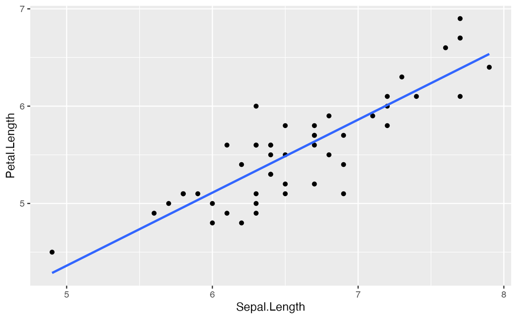

```r
as_tibble(iris) %>% filter(Species == "virginica") %>% ggplot(aes(Sepal.Length, Petal.Length)) + geom_point() + geom_smooth(method = "lm", formula = y~x, se = FALSE)
```

```r
as_tibble(iris) %>% filter(Species == "virginica") %>% lm(Petal.Length ~ Sepal.Length, .) %>% glance() %>% pull(r.squared) %>% sqrt()
```

```
[1] 0.8642247
```

Correlations of the data suggest the possible strength of linear model y ~ x.

```r
iris %>% select(-5) %>% cor()
```

```
             Sepal.Length Sepal.Width Petal.Length Petal.Width
Sepal.Length    1.0000000  -0.1175698    0.8717538   0.8179411
Sepal.Width    -0.1175698   1.0000000   -0.4284401  -0.3661259
Petal.Length    0.8717538  -0.4284401    1.0000000   0.9628654
Petal.Width     0.8179411  -0.3661259    0.9628654   1.0000000
```

### 5.1.12 Examples: WDI

- SP.DYN.LE00.IN: Life expectancy at birth, total (years)

```r
wdi_lifeExp <- WDI(indicator = c(lifeExp = "SP.DYN.LE00.IN"))
```

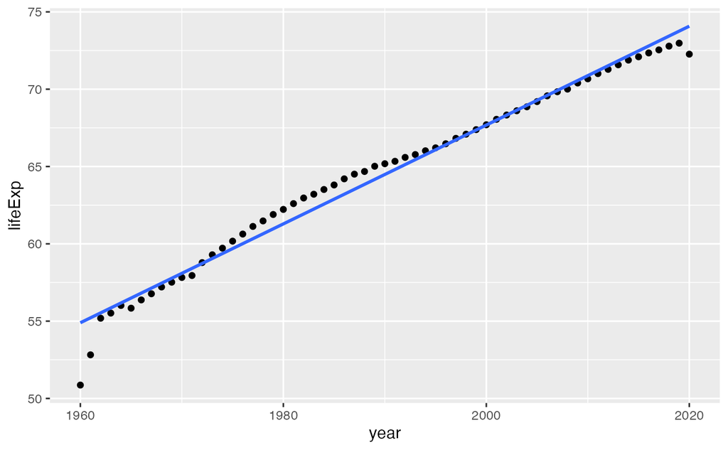

```r
wdi_lifeExp %>% filter(country == "World") %>% drop_na(lifeExp) %>%
  ggplot(aes(year, lifeExp)) + geom_point() + geom_smooth(method = "lm", se = FALSE)
```

```r
wdi_lifeExp %>% lm(lifeExp ~ year, .) %>% summary()
```

```
Call:
lm(formula = lifeExp ~ year, data = .)

Residuals:
    Min      1Q  Median      3Q     Max
-51.142  -7.297   1.782   7.873  19.139

Coefficients:
              Estimate Std. Error t value Pr(>|t|)
(Intercept) -5.574e+02  8.987e+00  -62.02   <2e-16 ***
year         3.123e-01  4.515e-03   69.15   <2e-16 ***
---
Signif. codes:  0 ‘***’ 0.001 ‘**’ 0.01 ‘*’ 0.05 ‘.’ 0.1 ‘ ’ 1

Residual standard error: 9.797 on 15202 degrees of freedom
  (1288 observations deleted due to missingness)
Multiple R-squared:  0.2393,    Adjusted R-squared:  0.2392
F-statistic:  4782 on 1 and 15202 DF,  p-value: < 2.2e-16
```

$$lifeExp \sim -557.4 + 0.3123 \cdot
year$$
Each year, life expectancy at birth increases approximately 0.3123 years. R-squared of this model is 0.2392, and the model explains 24%.

```r
wdi_lifeExp %>% filter(country == "World", year >= 1962, year <= 2019) %>% drop_na(lifeExp) %>%
  lm(lifeExp ~ year, .) %>% summary()
```

```
Call:
lm(formula = lifeExp ~ year, data = .)

Residuals:
     Min       1Q   Median       3Q      Max
-1.01769 -0.29535 -0.04302  0.38542  0.82106

Coefficients:
              Estimate Std. Error t value Pr(>|t|)
(Intercept) -5.543e+02  7.885e+00  -70.30   <2e-16 ***
year         3.110e-01  3.961e-03   78.52   <2e-16 ***
---
Signif. codes:  0 ‘***’ 0.001 ‘**’ 0.01 ‘*’ 0.05 ‘.’ 0.1 ‘ ’ 1

Residual standard error: 0.505 on 56 degrees of freedom
Multiple R-squared:  0.991, Adjusted R-squared:  0.9908
F-statistic:  6166 on 1 and 56 DF,  p-value: < 2.2e-16
```

### 5.1.13 BRICs

```r
mod_brics <- wdi_lifeExp %>% filter(country %in% c("Brazil", "Russian Federation", "India", "China")) %>% drop_na(lifeExp) %>% lm(lifeExp ~ year, .) %>% summary()
mod_brics$r.squared
```

```
[1] 0.5658162
```

```r
wdi_lifeExp %>% filter(country %in% c("Brazil", "Russian Federation", "India", "China")) %>% drop_na(lifeExp) %>%
  ggplot(aes(year, lifeExp)) + geom_point() + geom_smooth(formula = y~x, method = "lm", se = FALSE)
```

[figure not shown]

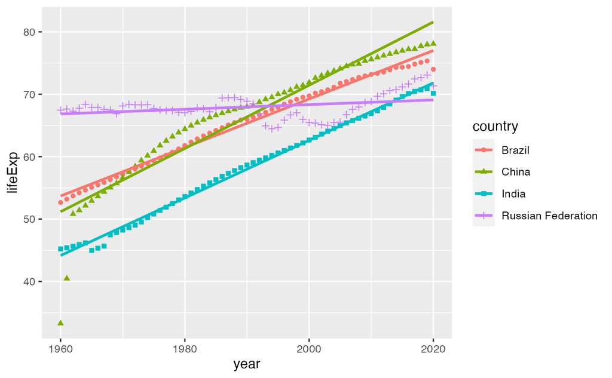

```r
wdi_lifeExp %>% filter(country %in% c("Brazil", "Russian Federation", "India", "China")) %>% drop_na(lifeExp) %>%
  ggplot(aes(year, lifeExp, color = country)) + geom_point(aes(shape = country)) + geom_smooth(formula = y~x, method = "lm", se = FALSE)
```

```r
country_model <- function(df) {
  lm(lifeExp ~ year, data = df)
}

by_country <- wdi_lifeExp %>% filter(country %in% c("Brazil", "Russian Federation", "India", "China")) %>% drop_na(lifeExp) %>% group_by(country) %>% nest()

by_country <- by_country %>%
  mutate(model = map(data, country_model))

by_country %>%
  mutate(tidy = map(model, broom::tidy)) %>%
  unnest(tidy)
```

| country | data | model | term | estimate | std.error | statistic | p.value |
| --- | --- | --- | --- | --- | --- | --- | --- |
| Brazil |  |  | (Intercept) | -708.00035854 | 10.622859002 | -66.6487580 | 3.053522e-57 |
| Brazil |  |  | year | 0.38862041 | 0.005337911 | 72.8038365 | 1.770961e-59 |
| China |  |  | (Intercept) | -941.97624855 | 47.863990779 | -19.6802697 | 1.318718e-27 |
| China |  |  | year | 0.50671137 | 0.024051315 | 21.0679276 | 3.875610e-29 |
| India |  |  | (Intercept) | -859.81741565 | 8.513118188 | -100.9991165 | 8.460482e-68 |
| India |  |  | year | 0.46121354 | 0.004277781 | 107.8160602 | 1.830987e-69 |
| Russian Federation |  |  | (Intercept) | -6.41700873 | 26.905736112 | -0.2384997 | 8.123200e-01 |
| Russian Federation |  |  | year | 0.03738093 | 0.013519941 | 2.7648737 | 7.587858e-03 |

```r
by_country %>%
  mutate(glance = map(model, broom::glance)) %>%
  unnest(glance)
```

| country | data | model | r.squared | adj.r.squared | sigma | statistic | p.value | df | logLik | AIC | BIC | deviance | df.residual | nobs |
| --- | --- | --- | --- | --- | --- | --- | --- | --- | --- | --- | --- | --- | --- | --- |
| Brazil |  |  | 0.9889913 | 0.98880471 | 0.7340356 | 5300.398605 | 1.770961e-59 | 1 | -66.67742 | 139.3548 | 145.6875 | 31.78969 | 59 | 61 |
| China |  |  | 0.8826706 | 0.88068192 | 3.3073838 | 443.857573 | 3.875610e-29 | 1 | -158.50410 | 323.0082 | 329.3408 | 645.38847 | 59 | 61 |
| India |  |  | 0.9949501 | 0.99486447 | 0.5882533 | 11624.302841 | 1.830987e-69 | 1 | -53.17203 | 112.3441 | 118.6767 | 20.41647 | 59 | 61 |
| Russian Federation |  |  | 0.1147060 | 0.09970101 | 1.8591763 | 7.644527 | 7.587858e-03 | 1 | -123.36663 | 252.7333 | 259.0659 | 203.93565 | 59 | 61 |

### 5.1.14 Government Expenditure, (% of GDP)

```r
wdi_cache <- read_rds("data/wdi_cache.RData")
```

```r
WDIsearch("expenditure", "name", cache = wdi_cache) %>%
  inner_join(WDIsearch("% of GDP", "name", cache = wdi_cache))
```

| indicator | name |
| --- | --- |
| GB.XPD.DEFN.GDP.ZS | Defense expenditure (% of GDP) |
| GB.XPD.RSDV.GD.ZS | Research and development expenditure (% of GDP) |
| GB.XPD.TOTL.GD.ZS | Expenditure, total (% of GDP) |
| GB.XPD.TOTL.GDP.ZS | Total expenditure (% of GDP) |
| IE.ICT.TOTL.GD.ZS | Information and communication technology expenditure (% of GDP) |
| MS.MIL.XPND.GD.ZS | Military expenditure (% of GDP) |
| NE.CON.GOVT.ZS | General government final consumption expenditure (% of GDP) |
| NE.CON.PETC.ZS | Household final consumption expenditure, etc. (% of GDP) |
| NE.CON.PRVT.ZS | Households and NPISHs final consumption expenditure (% of GDP) |
| NE.CON.TETC.ZS | Final consumption expenditure, etc. (% of GDP) |

[output cut: 19 more lines]

```r
wdi_cache$series %>% filter(grepl("expenditure", name), grepl("% of GDP", name))
```

| indicator | name | description | sourceDatabase | sourceOrganization |
| --- | --- | --- | --- | --- |
| GB.XPD.DEFN.GDP.ZS | Defense expenditure (% of GDP) |  | WDI Database Archives |  |
| GB.XPD.RSDV.GD.ZS | Research and development expenditure (% of GDP) | Gross domestic expenditures on research and development (R&D), expressed as a percent of GDP. They include both capital and current expenditures in the four main sectors: Business enterprise, Governme… | World Development Indicators | UNESCO Institute for Statistics (UIS). UIS.Stat Bulk Data Download Service. Accessed October 24, 2022. https://apiportal.uis.unesco.org/bdds. |
| GB.XPD.TOTL.GDP.ZS | Total expenditure (% of GDP) |  | WDI Database Archives |  |
| IE.ICT.TOTL.GD.ZS | Information and communication technology expenditure (% of GDP) | Information and communications technology expenditures include computer hardware (computers, storage devices, printers, and other peripherals); computer software (operating systems, programming tools,… | Africa Development Indicators | World Information Technology and Services Alliance, Digital Planet: The Global Information Economy, and Global Insight, Inc. |
| MS.MIL.XPND.GD.ZS | Military expenditure (% of GDP) | Military expenditures data from SIPRI are derived from the NATO definition, which includes all current and capital expenditures on the armed forces, including peacekeeping forces; defense ministries a… | World Development Indicators | Stockholm International Peace Research Institute (SIPRI), Yearbook: Armaments, Disarmament and International Security. |
| NE.CON.GOVT.ZS | General government final consumption expenditure (% of GDP) | General government final consumption expenditure (formerly general government consumption) includes all government current expenditures for purchases of goods and services (including compensation of e… | World Development Indicators | World Bank national accounts data, and OECD National Accounts data files. |
| NE.CON.PETC.ZS | Household final consumption expenditure, etc. (% of GDP) | Household final consumption expenditure (formerly private consumption) is the market value of all goods and services, including durable products (such as cars, washing machines, and home computers), p… | WDI Database Archives | World Bank national accounts data, and OECD National Accounts data files. |
| NE.CON.PRVT.ZS | Households and NPISHs final consumption expenditure (% of GDP) | Household final consumption expenditure (formerly private consumption) is the market value of all goods and services, including durable products (such as cars, washing machines, and home computers), p… | World Development Indicators | World Bank national accounts data, and OECD National Accounts data files. |
| NE.CON.TETC.ZS | Final consumption expenditure, etc. (% of GDP) | Final consumption expenditure (formerly total consumption) is the sum of household final consumption expenditure (private consumption) and general government final consumption expenditure (general gov… | WDI Database Archives | World Bank national accounts data, and OECD National Accounts data files. |
| NE.CON.TOTL.ZS | Final consumption expenditure (% of GDP) | Final consumption expenditure (formerly total consumption) is the sum of household final consumption expenditure (private consumption) and general government final consumption expenditure (general gov… | World Development Indicators | World Bank national accounts data, and OECD National Accounts data files. |

[output cut: 18 more lines]

- NY.GDP.PCAP.KD: GDP per capita (constant 2015 US$)
- SP.DYN.LE00.IN: Life expectancy at birth, total (years)
- SP.POP.TOTL: Population, total
- GB.XPD.RSDV.GD.ZS: Research and development expenditure (% of GDP) - 2
- MS.MIL.XPND.GD.ZS: Military expenditure (% of GDP) - 6
- SE.XPD.TOTL.GD.ZS: Government expenditure on education, total (% of GDP)

```r
wdi_world <- WDI(country = "1W", indicator = c("NY.GDP.PCAP.KD", "SP.DYN.LE00.IN","SP.POP.TOTL", "GB.XPD.RSDV.GD.ZS", "IE.ICT.TOTL.GD.ZS", "MS.MIL.XPND.GD.ZS", "SE.XPD.TOTL.GD.ZS", "SH.XPD.TOTL.ZS"), 2000)
```

```r
wdi_world <- WDI(country = "1W", indicator = c(gdpPcap = "NY.GDP.PCAP.KD", lifeExp = "SP.DYN.LE00.IN", pop = "SP.POP.TOTL", research = "GB.XPD.RSDV.GD.ZS", military = "MS.MIL.XPND.GD.ZS", education = "SE.XPD.TOTL.GD.ZS"), 1990)
```

```r
wdi_world
```

```r
wdi_world %>% drop_na() %>% select(-c(1,2,3,5,6,7)) %>%
  pivot_longer(-1, names_to = "indicator", values_to = "value") %>%
  ggplot(aes(year, value, col=indicator)) + geom_line()
```

```r
wdi_world %>% drop_na() %>% select(-c(1,2,3)) %>% cor()
```

- lifeExp ~ research + education
- gdpPcap ~ research + education

```r
wdi_world %>% drop_na() %>% select(-c(1,2,3,5,6,7,9)) %>%
  pivot_longer(-1, names_to = "indicator", values_to = "value") %>%
  ggplot(aes(year, value, col=indicator)) + geom_line()
```

```r
wdi_world <- WDI(country = "all", indicator = c(gdpPcap = "NY.GDP.PCAP.KD", lifeExp = "SP.DYN.LE00.IN", pop = "SP.POP.TOTL", research = "GB.XPD.RSDV.GD.ZS", military = "MS.MIL.XPND.GD.ZS", education = "SE.XPD.TOTL.GD.ZS"), 1990, extra = TRUE, cache = wdi_cache)
```

```r
wdi_world
```

SE.XPD.TOTL.GB.ZS: Government expenditure on education, total (% of government expenditure) SE.XPD.TOTL.GD.ZS: Government expenditure on education, total (% of GDP) SE.XPD.PRIM.PC.ZS: Government expenditure per student, primary (% of GDP per capita) MS.MIL.XPND.ZS: Military expenditure (% of general government expenditure) SE.XPD.TERT.ZS: Expenditure on tertiary education (% of government expenditure on education) —

```r
mod_e <- lm(lifeExp ~ education, wdi_world); mod_e
```

```r
wdi_world %>% ggplot(aes(education, lifeExp)) + geom_point() + geom_smooth(formula = y ~ x, method = "lm", se=FALSE)
```

```r
wdi_world %>% filter(income != "Aggregates") %>% drop_na(education, lifeExp) %>% ggplot(aes(education, lifeExp)) + geom_point() + geom_smooth(formula = y ~ x, method = "lm", se=FALSE)
```

```r
wdi_world_el <- wdi_world %>% select(country, year, education, lifeExp, gdpPcap, pop, research, military, region, income) %>% filter(income != "Aggregates") %>% drop_na(education, lifeExp)
```

```r
wdi_world_el %>% ggplot(aes(education)) + geom_histogram()
```

```r
wdi_world_el %>% filter(year==2020) %>% ggplot(aes(x = income, y = education, fill = income)) + geom_boxplot()
```

```r
wdi_world_el %>% filter(year==2020) %>% arrange(desc(education))
```

```r
wdi_world_el %>% filter(year==2020) %>% arrange(desc(education))
```

```r
wdi_world_el %>% filter(year==2020) %>% lm(gdpPcap ~ education, .)
```

```r
wdi_world_el %>% filter(year==2020) %>% lm(gdpPcap ~ education, .) %>% glance()
```

```r
wdi_world_el %>% lm(lifeExp ~ education + research + military, .) %>% glance()
```

```r
wdi_world_el %>% lm(lifeExp ~ education + research + military, .) %>% tidy()
```

$$lifeExp \sim 70.22 + 0.08\cdot education
+ 3.84 \cdot research - 0.07 \cdot military$$

```r
wdi_world_el %>% lm(gdpPcap ~ education + research + military, .) %>% tidy()
```

```r
wdi_world_el %>% lm(gdpPcap ~ education + research + military, .) %>% glance()
```

$$gdpPcap \sim 1077 + 1024\cdot education
+ 12792 \cdot research - 967 \cdot military$$

```r
mod_r <- lm(lifeExp ~ research, wdi_world); mod_e
```

### 5.1.15 model and Linear Regression Quick Reference

- R4DS: Model basics
  - https://r4ds.had.co.nz/model-basics.html

For explanation of other indices, please see.

- r-statistics.co by Selva Prabhakaran:
  - http://r-statistics.co/Linear-Regression.html

### 5.1.16 DA4R 2021

```r
library(modelr)
t_cars <- as_tibble(cars)
(mod <- lm(dist ~ speed, data = t_cars))
```

```r
t_cars %>% add_predictions(mod) %>% add_residuals(mod)
```

```r
augment(mod)
```

```r
glance(mod)
```

```r
tidy(mod)
```

```r
mod %>% glance()
```

```r
ggplot(t_cars, aes(speed, dist)) + geom_point() +
  geom_abline(slope = coef(mod)[[2]], intercept = coef(mod)[[1]])
```

```r
ggplot(t_cars, aes(speed, dist)) + geom_jitter() +
  geom_smooth(method = "lm", se = FALSE)
```

### 5.1.17 Predictions $\hat{y} = a_1 + a_2x$ and Residuals $y - \hat{y}$

```r
(mod_table <- t_cars %>% add_predictions(mod) %>% add_residuals(mod, var = "resid"))
```

```r
mod_table %>% ggplot() + geom_jitter(aes(speed, resid)) + geom_hline(yintercept = 0)
```

### 5.1.18 geom_jitter()

```r
t_cars %>% group_by(speed, dist) %>%
  summarize(count = n()) %>% arrange(desc(count))
```

Galton’s data. Regression. https://icu-hsuzuki.github.io/da4r2021/model.html

Normalization, standalization

SDGs Academy

Trend

```r
df4 <- WDI(
  country="all",
  indicator = c("SP.POP.TOTL","MS.MIL.XPND.GD.ZS","MS.MIL.TOTL.P1","NY.GDP.MKTP.CD"),
  start = 1960,
  end = NULL,
  extra = FALSE,
  cache = NULL,
  latest = NULL,
  language = "en"
)
```

```r
colnames(df4) <- c("Country","iso2c","iso3c","Year","Population","Mil_Exp","Total_Mil_HC","GDP")
df4
```

### 5.1.19 Regression Line

```r
df_wdi_poverty <- WDI(
  country = "all",
  indicator = c(national_poverty_rate = "SI.POV.NAHC", multidimentional_poverty_rate = "SI.POV.MDIM", gdpPercap = "NY.GDP.PCAP.KD", gini_indx = "SI.POV.GINI"), start = 1990,
    end = 2021,
  extra = TRUE
)
```

```r
write_csv(df_wdi_poverty, "data/wdi_poverty")
```

```r
df_wdi_poverty
```

```r
df_wdi_poverty %>%
  group_by(country, year) %>%
  mutate(mean_gdp_country = mean(gdpPercap)) %>%
  mutate(mean_poverty_country= mean(national_poverty_rate)) %>%
  ungroup() %>%
    filter(!is.na(income)) %>%   filter(!(income=="Aggregates")) %>% ggplot(aes(x = log10(mean_gdp_country))) + geom_point(aes(y = mean_poverty_country, color = income)) +  labs(x = "GDP per capita", y = "poverty rate (% of population)", title = "Poverty rates and GDP per capita", subtitle="world countries, 1990-2021 average, by income level")
```

```r
df_wdi_poverty %>%
  group_by(country, year) %>%
  mutate(mean_gdp_country = mean(gdpPercap)) %>%
  mutate(mean_multipoverty_country= mean(multidimentional_poverty_rate)) %>%
  ungroup() %>%
    filter(!(region=="Aggregates")) %>% filter(!is.na(region)) %>% ggplot(aes(x = log10(mean_gdp_country))) + geom_point(aes(y = mean_multipoverty_country, color = region)) +  labs(x = "GDP per capita", y = "Multidimentinal poverty rate (% of population)", title = "Multidimentional Poverty rates and GDP per capita", subtitle="world countries, 1990-2021 average, by region")
```

index sdg, ghi, academy

moocs

R4DS: Model basics https://r4ds.had.co.nz/model-basics.html modelr: https://modelr.tidyverse.org

Tidymodels: https://www.tidymodels.org

(Modern Dive: https://moderndive.com/index.html pakcage: moderndive)

Tidyverse Skills for Data Science https://jhudatascience.org/tidyversecourse/ https://jhudatascience.org/tidyversecourse/model.html

machine learning:A Gentle Introduction to tidymodels https://rviews.rstudio.com/2019/06/19/a-gentle-intro-to-tidymodels/

Tidy Modeling with R https://www.tmwr.org

Galtons: DA4R2021: C.3.2.3 Galton’s Example

## 5.2 Roudups

### 5.2.1 R Markdown Revisited

Presentation: Submit an R Notebook (with codes used in the presentation), and PowerPoint file or other files used for your presentation, if any. If you use R Notebook for your presentation, you do not need to submit extra files.

Final Paper: Submit an R Notebook (with codes as a work file), and a PDF (rendered directly from an R Notebook, or created from Word) - Maximum pages of PDF is eight.

Format of Presentation - R Notebook is fine and slide presentation in various format is also fine

[] Format of Paper - PDF or MS Word [] Code chunk [] PDF [] MS Word with template [] PowerPoint with template

#### 5.2.1.1 Literate Programming and Reproducible Research

Importing Data:

1. Read a csv file: `read_csv("data/file_name.csv")`
2. Download and import using a url of a csv file: `read_csv(url)`
3. Read an Excel file: `readxl::read_excel("data/excel_file_name.xlsx")`
4. Read from the clipboard: `read_delim(clipboard())`
- zip file:
  - copy the url
  - wir1to10 <- “https://wir2022.wid.world/www-site/uploads/2022/03/WIR2022TablesFigures-Chapter.zip”
  - download.file(wir1to10, destfile = “data/wir1to10.zip”)
  - unzip(“data/wir1to10.zip”, exdir = “data”)
  - list.files(“data/WIR2022TablesFigures-Chapter”)
  - excel_sheets(“data/WIR2022TablesFigures-Chapter/WIR2022TablesFigures-Chapter1.xlsx”)
  - df <- read_delim(clipboard()); df
  - Not reproducible unless clearly explained.

#### 5.2.1.2 Code Chunk Options

https://yihui.org/knitr/options/

- Chunk Name
- Output: use document default
  - Show code and output: echo=TRUE, eval=TRUE - Default
  - Show output only: echo=FALSE
  - Show nothing (run code): include=FALSE
  - Show nothing (don’t run code): include=FALSE, eval=FALSE
- Show message: message=TRUE, FALSE
- Show warning: warning=TRUE, FALSE
- Use Paged Tables: paged.print=TRUE, FALSE
- Use custom figure size: width and height in inch.
- You can use Hide Code and Show Code option on the rendered Notebook file.

#### 5.2.1.3 Presentation and Paper

1. Data Source
2. Variables
3. Problems
4. Visualization
5. Model
6. Conclusions and Further Research

   WDI, WIR, etc

#### 5.2.1.4 Word

Custom Word templates: https://bookdown.org/yihui/rmarkdown-cookbook/word-template.html

You can apply the styles defined in a Word template document to new Word documents generated from R Markdown. Such a template document is also called a “style reference document.” The key is that you have to create this template document from Pandoc first, and change the style definitions in it later. Then pass the path of this template to the reference_docx option of word_document

```
---
 word_document:
    reference_docx: "template.docx"
---
```

#### 5.2.1.5 PowerPoint

PowerPoint presentation: https://bookdown.org/yihui/rmarkdown/powerpoint-presentation.html

Custom templates: https://bookdown.org/yihui/rmarkdown/powerpoint-presentation.html#ppt-templates

```
---
  powerpoint_presentation:
    reference_doc: my-styles.pptx
---
```

https://support.microsoft.com/en-us/office/create-and-save-a-powerpoint-template-ee4429ad-2a74-4100-82f7-50f8169c8aca

YouTube: How To Create A PowerPoint Template

## 5.3 The Week Six Assignment - Assignment Five (in Moodle)

- Create an R Notebook of a Data Analysis containing the following and submit the rendered HTML file (eg. `a5_123456.nb.html` by replacing 123456 with your ID), and a PDF (or MS Word File).
  1. create an R Notebook using the R Notebook Template in Moodle, save as `a3_123456.Rmd`,
  2. write your name and ID and the contents,
  3. run each code block,
  4. preview to create `a5_123456.nb.html`,
  5. render (or knit) PDF, or Word (and then PDF)
  6. submit `a5_123456.nb.html` and PDF (or Word) to Moodle.
1. Choose a data with at least two numerical variables. One of them can be the year.
   - Information of the data
   - Explain why you chose the data
   - List questions you want to study
2. Explore the data using visualization using `ggplot2`
   - Create various charts, and write observed comments
   - Apply a (linear regression) model, and draw a regression line to at least one chart, and write your conclusion based on the model using the slope value and R squared (and/or adjusted R squared).
3. Observations based on your data visualization, and difficulties and questions encountered if any.

**Due:** 2023-01-30 23:59:00. Submit your R Notebook file, and a PDF file (or a MS Word file) in Moodle (The Fifth Assignment). Due on Monday!

- Trend - add a regression line
- Measurement, how much, confident
- Visualization vs modeling
- Lm, Lm summary - estimate and r squared
- Explanation of r squared: 6.1.13, 6.2.4 Useful Mathematical Formula https://icu-hsuzuki.github.io/da4r2021/eda5.html
- Adjusted r squared
- Correlation
- Iris - correlation, confounder
- WDI life expectancy ~ gdpPercap, budget of education, budget of Military power, budget of …
  - Problem of modeling
- Broom - comparison of r squared
- Correlation is not causation
- History of Regression Analysis
- Nightingale
- Anna Karenina Principle
- Data Science - Statistics - Mathematics — Central limit theorem
- AI - my motivation and chat gpt

> “Tidy data sets are all alike; but every messy data set is messy in its own way.” — Hadley Wickham

> “all happy families are all alike; each unhappy family is unhappy in its own way” - Tolstoy’s Anna Karenina

### 5.3.1 Roundups